# MIDTERM PROJECT SCRIPT FOR MULTI-CLASS CLASSIFICATION USING FOUR SUPERVISED LEARNING MODELS FROM SCIKIT-LEARN NAMELY PERCEPTRON, LOGISTIC REGRESSION, SVM AND KNN

### Python imports

```python
import numpy as np
import pandas as pd
from matplotlib import pyplot as plt
from matplotlib.colors import ListedColormap
import csv
from sklearn import datasets
from sklearn.cross_validation import train_test_split
from sklearn.preprocessing import StandardScaler
from sklearn.linear_model import Perceptron
from sklearn.metrics import accuracy_score
from sklearn.linear_model import LogisticRegression
from sklearn.svm import SVC
from sklearn.neighbors import KNeighborsClassifier
```

### Loading the generated dataset using script *dataGen_Script.py* from *midterm_data.csv* file

```python
#Loading into a dataframe df
df = pd.read_csv('midterm_data.csv')
print(df.tail())
print("Dimensions of data: ",df.shape)
```

```
           X1        X2  Class
295  1.484537  6.443709      3
296  2.302164  6.158445      3
297  1.115258  6.945472      3
298  1.902292  6.298797      3
299  1.616267  6.310493      3
Dimensions of data:  (300, 3)
```

We see that the dataset is labelled and has 300 samples and 3 columns of which 2 are the features X1 and X2 columns and the last one is the class label.

### Extracting all the samples from the above dataframe *df* and the 2 features X1 and X2 (or column names) into X and class labels (third column) into y

```python
X = df.iloc[:, [0,1]].values
y = df.iloc[:,2].values
print(y)

#Check the unique class labels to prepare for classification
print('Class labels:', np.unique(y))
```

```
[1 1 1 1 1 1 1 1 1 1 1 1 1 1 1 1 1 1 1 1 1 1 1 1 1 1 1 1 1 1 1 1 1 1 1 1 1
 1 1 1 1 1 1 1 1 1 1 1 1 1 1 1 1 1 1 1 1 1 1 1 1 1 1 1 1 1 1 1 1 1 1 1 1 1
 1 1 1 1 1 1 1 1 1 1 1 1 1 1 1 1 1 1 1 1 1 1 1 1 1 1 2 2 2 2 2 2 2 2 2 2 2
 2 2 2 2 2 2 2 2 2 2 2 2 2 2 2 2 2 2 2 2 2 2 2 2 2 2 2 2 2 2 2 2 2 2 2 2 2
 2 2 2 2 2 2 2 2 2 2 2 2 2 2 2 2 2 2 2 2 2 2 2 2 2 2 2 2 2 2 2 2 2 2 2 2 2
 2 2 2 2 2 2 2 2 2 2 2 2 2 2 2 3 3 3 3 3 3 3 3 3 3 3 3 3 3 3 3 3 3 3 3 3 3
 3 3 3 3 3 3 3 3 3 3 3 3 3 3 3 3 3 3 3 3 3 3 3 3 3 3 3 3 3 3 3 3 3 3 3 3 3
 3 3 3 3 3 3 3 3 3 3 3 3 3 3 3 3 3 3 3 3 3 3 3 3 3 3 3 3 3 3 3 3 3 3 3 3 3
 3 3 3 3]
Class labels: [1 2 3]
```

And the samples belong to the class labels that are of 3 types or 3 numbers: 1, 2 and 3. X variable has X1 and X2 columns, y variable has class labels for all the 300 samples.

### Splitting the dataset into training and test datasets

```python
#random state is for initial shuffling of training dataset after each epoch
X_train, X_test, y_train, y_test = train_test_split(X,y,test_size=0.3,random_state=0)
```

Splitted data into 70% training and 30% test data.

### Feature Scaling for Optimal Performance

```python
#Standardizing the features
sc = StandardScaler()
sc.fit(X_train)
X_train_std = sc.transform(X_train)
X_test_std = sc.transform(X_test)

#Stack arrays so as to make a single array vertically and horizontally
X_combined_std = np.vstack((X_train_std, X_test_std))
y_combined = np.hstack((y_train, y_test))
```

### Plotting function for decision regions in the Classification Problem

```python
def plot_decision_regions(X, y, classifier, test_idx=None, resolution=0.02):

    # setup marker generator and color map
    markers = ('s', 'x', 'o', '^', 'v')
    colors = ('red', 'blue', 'lightgreen', 'gray', 'cyan')
    cmap = ListedColormap(colors[:len(np.unique(y))])

    # plot the decision surface
    x1_min, x1_max = X[:, 0].min() - 1, X[:, 0].max() + 1
    x2_min, x2_max = X[:, 1].min() - 1, X[:, 1].max() + 1
    xx1, xx2 = np.meshgrid(np.arange(x1_min, x1_max, resolution),
                           np.arange(x2_min, x2_max, resolution))
    Z = classifier.predict(np.array([xx1.ravel(), xx2.ravel()]).T)
    Z = Z.reshape(xx1.shape)
    plt.contourf(xx1, xx2, Z, alpha=0.3, cmap=cmap)
    plt.xlim(xx1.min(), xx1.max())
    plt.ylim(xx2.min(), xx2.max())

    for idx, cl in enumerate(np.unique(y)):
        plt.scatter(x=X[y == cl, 0],
                    y=X[y == cl, 1],
                    alpha=0.8,
                    c=colors[idx],
                    marker=markers[idx],
                    label=cl,
                    edgecolor='black')

    # highlight test samples
    if test_idx:
        # plot all samples
        X_test, y_test = X[test_idx, :], y[test_idx]

        plt.scatter(X_test[:, 0],
                    X_test[:, 1],
                    c='',
                    edgecolor='black',
                    alpha=1.0,
                    linewidth=1,
                    marker='o',
                    s=100,
                    label='test set')
```

### Model I --> Perceptron: Training a perceptron using Scikit-learn and Plotting with Decision Regions and Classified Data by specifying the indices of samples (test data)

```python
##Multi-class classification using Scikit-learn perceptron
ppn = Perceptron(max_iter=50, eta0=0.1, random_state=1)
ppn.fit(X_train_std, y_train)
y_pred = ppn.predict(X_test_std)
print(y_pred)
print("Weights assigned to the features: ",ppn.coef_)
print('Number of Misclassified samples: %d' % (y_test != y_pred).sum())
#print('Model Accuracy: %.2f' % accuracy_score(y_test, y_pred))
print('Model Accuracy: %.2f' % ppn.score(X_test_std, y_test))
```

```
[3 2 1 3 3 2 3 3 1 2 3 1 2 3 1 1 3 1 3 2 2 2 2 2 3 1 2 3 3 3 1 1 1 2 3 3 2
 2 3 1 3 1 1 1 1 2 3 1 1 1 1 3 2 2 1 3 2 1 3 2 2 2 1 3 3 3 3 2 1 1 2 3 3 1
 2 3 1 1 2 2 2 2 3 3 3 1 3 3 3 3]
Weights assigned to the features:  [[-0.19368789 -0.03674891]
 [ 0.53036155 -0.41125304]
 [-0.04578494  0.20515548]]
Number of Misclassified samples: 2
Model Accuracy: 0.98
```

Training the perceptron model using the standardized training data. 30% of test data i.e. last 90 samples are the test data i.e. from 210 to 300 samples. Plot with classification and decision regions is stored in a file called *ppn_classify_plot.png*.

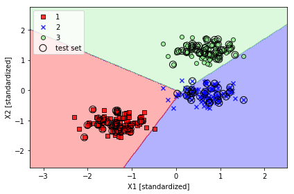

```python
plot_decision_regions(X=X_combined_std, y=y_combined,
                      classifier=ppn, test_idx=range(210, 300))
plt.xlabel('X1 [standardized]')
plt.ylabel('X2 [standardized]')
plt.legend(loc='upper left')
plt.tight_layout()
plt.savefig('ppn_classify_plot.png', dpi=300)
plt.show()
```

### Model II --> Logistic Regression: Training a Logistic Regression model using Scikit-learn and Plotting with Decision Regions and Classified Data by specifying the indices of samples (test data)

```
Number of Misclassified samples: 0
Accuracy: 1.00
```

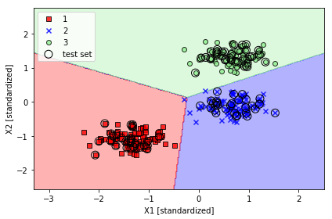

```python
lr = LogisticRegression(C=100.0, random_state=1)
lr.fit(X_train_std, y_train)
y_pred_lr = lr.predict(X_test_std)
print('Number of Misclassified samples: %d' % (y_test != y_pred_lr).sum())
#print('Accuracy: %.2f' % accuracy_score(y_test, y_pred_lr))
print('Accuracy: %.2f' % lr.score(X_test_std, y_test))
plot_decision_regions(X_combined_std, y_combined,
                      classifier=lr, test_idx=range(210, 300))
plt.xlabel('X1 [standardized]')
plt.ylabel('X2 [standardized]')
plt.legend(loc='upper left')
plt.tight_layout()
plt.savefig('lr_classify_plot.png', dpi=300)
plt.show()
```

### Model III --> Support Vector Machines (SVM): Training a SVM model using Scikit-learn and Plotting with Decision Regions and Classified Data by specifying the indices of samples (test data)

Training SVM model using Scikit-learn and linear kernel.

```
Number of Misclassified samples: 0
Accuracy: 1.00
```

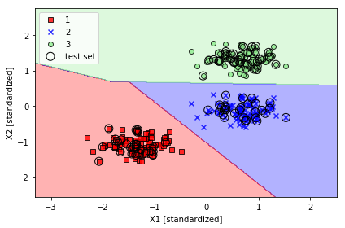

```python
#With linear kernel
svm = SVC(kernel='linear', C=1.0, random_state=1)
svm.fit(X_train_std, y_train)
y_pred_svm = svm.predict(X_test_std)
print('Number of Misclassified samples: %d' % (y_test != y_pred_svm).sum())
#print('Accuracy: %.2f' % accuracy_score(y_test, y_pred_svm))
print('Accuracy: %.2f' % svm.score(X_test_std, y_test))

plot_decision_regions(X_combined_std,
                      y_combined,
                      classifier=svm,
                      test_idx=range(210, 300))
plt.xlabel('X1 [standardized]')
plt.ylabel('X2 [standardized]')
plt.legend(loc='upper left')
plt.tight_layout()
plt.savefig('svmlin_classify_plot.png', dpi=300)
plt.show()
```

Training SVM model using Scikit-learn and non-linear kernel called Radial Basis Function (RBF) for softer decision boundary.

```
Number of Misclassified samples: 0
Accuracy: 1.00
```

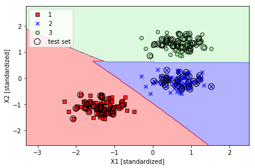

```python
svm_nonlinear = SVC(kernel='rbf',random_state=0,gamma=0.2, C=1.0)
svm_nonlinear.fit(X_train_std, y_train)
y_pred_svm_nl = svm_nonlinear.predict(X_test_std)
print('Number of Misclassified samples: %d' % (y_test != y_pred_svm_nl).sum())
#print('Accuracy: %.2f' % accuracy_score(y_test, y_pred_svm_nl))
print('Accuracy: %.2f' % svm_nonlinear.score(X_test_std, y_test))
plot_decision_regions(X_combined_std,
                      y_combined,
                      classifier=svm_nonlinear,
                      test_idx=range(210, 300))
plt.xlabel('X1 [standardized]')
plt.ylabel('X2 [standardized]')
plt.legend(loc='upper left')
plt.tight_layout()
plt.savefig('svmnon_lin_classify_plot.png', dpi=300)
plt.show()
```

### Model IV --> K-Nearest Neighbours (KNN): Training a KNN model using Scikit-learn and Plotting with Decision Regions and Classified Data by specifying the indices of samples (test data)

with p=2 i.e. Euclidean distance metric

```
Number of Misclassified samples: 0
Accuracy: 1.00
```

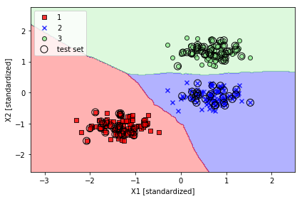

```python
knn = KNeighborsClassifier(n_neighbors=5,
                           p=2,
                           metric='minkowski')
knn.fit(X_train_std, y_train)

y_pred_knn = knn.predict(X_test_std)
print('Number of Misclassified samples: %d' % (y_test != y_pred_knn).sum())
#print('Accuracy: %.2f' % accuracy_score(y_test, y_pred_knn))
print('Accuracy: %.2f' % knn.score(X_test_std, y_test))

plot_decision_regions(X_combined_std, y_combined,
                      classifier=knn, test_idx=range(210, 300))

plt.xlabel('X1 [standardized]')
plt.ylabel('X2 [standardized]')
plt.legend(loc='upper left')
plt.tight_layout()
plt.savefig('knn_classify_plot.png', dpi=300)
plt.show()
```

### Summary of the models with misclassified samples and accuracy (in %)

Table below lists the four trained models on our dataset with number of misclassified samples and accuracy.

[output not shown]

### Comparing the four models

Script and plot showing how the four models (perceptron, logistic regression, svm linear and non-linear and knn) perform on our *midterm_data.csv* dataset.

```
training Perceptron
training LR
training SVM_Linear
training SVM_RBF
training KNN
```

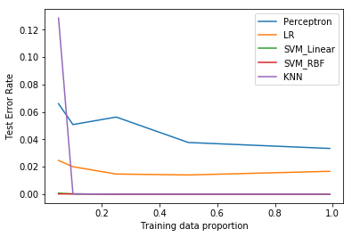

```python
#Proportion of samples
heldout = [0.95, 0.90, 0.75, 0.50, 0.01]
rounds = 20

#Classifiers (supervised learning models used in this analysis) as a list and initialized
classifiers = [
    ("Perceptron", Perceptron(max_iter=50, eta0=0.1, random_state=1)),
    ("LR", LogisticRegression(C=100.0, random_state=1)),
    ("SVM_Linear",SVC(kernel='linear', C=1.0, random_state=1)),
    ("SVM_RBF",SVC(kernel='rbf',random_state=0,gamma=0.2, C=1.0)),
    ("KNN",KNeighborsClassifier(n_neighbors=5,
                           p=2,
                           metric='minkowski'))
]

#Training sample size proportion
xx = 1. - np.array(heldout)

#Computing the score below by training the models and predicting the class labels and classifying them by looping through the list of classifiers declared above
for name, clf in classifiers:
    print("training %s" % name)
    rng = np.random.RandomState(42)
    yy = []
    for i in heldout:
        yy_ = []
        for r in range(rounds):
            X_train, X_test, y_train, y_test = \
                train_test_split(X, y, test_size=i, random_state=rng)
            clf.fit(X_train, y_train)
            y_pred = clf.predict(X_test)
            yy_.append(1 - np.mean(y_pred == y_test))
        yy.append(np.mean(yy_))
    plt.plot(xx, yy, label=name)

plt.legend(loc="upper right")
plt.xlabel("Training data proportion")
plt.ylabel("Test Error Rate")
plt.show()
```

From the above analysis we see that the test error rate for **perceptron** model initially shows few misclassifications but reduces it as the training data proportion increases. Whereas the **Logistic Regression** model almost stays constant at low test error rate for any training set proportion at 0.02. **SVM Linear** and **SVM RBF** have 0 test error rate proving to be the best models for our current dataset. **KNN** model follows the same trend as **Logistic Regression** model but starting with higher test error rate and sudden reduction to 0 test error rate with the increase in training dataset. This shows and conforms to the fact that KNN remembers the dataset from the point it stops misclassifying.